# Stat435_HW3

Su Huang

5/3/2022

### Problem 1

#### a).

```r
set.seed(2)
y <- rnorm(100)
x <- matrix(rnorm(10000*100), ncol=10000)
simulated_data = data.frame(x, y)
lm_fit <- lm(y ~ x, data=simulated_data)
```

Since they are both random sample, x and y are independent on each other. y = ~ Norm(0,1). $\beta = 0$ and other coefficients = 0 as well.

#### b).

The $\epsilon = 1$ because the irreducible error is simple the variance of the function since y = norm(0, 1) where sd = 1.

#### c).

i). Bias = $E[\hat{f(x)}]-f(x)$. Since $\hat{f(x)}=0$ and we have norm(0,1) for f(x), f(x) = 0 Thus, Bias = $E[0]-0 = 0$

ii). variance = $Var(\hat{f(x)})=var(0)$. Since $\hat{f(x)}=0$ Thus, Variance = 0

iii). The $EPE=Var(\epsilon)+Bias^2(\hat{f(x)})+Var(\hat{f(x)})=Var(\epsilon)=1$

iv). The performance on validation set is $CV_{vsa} = \frac{1}{nval} \sum_{i \in \text{val set}} (\hat{f_{train}(xi)} - y_i)^2 = \frac{1}{nval} \sum_{i \in \text{val set}} (y_i)^2 = E(f(x)^2) = Var(f(x)) + E(f(x))^2 = 1$

```r
set.seed(2)
train <- sample(100, 50)

train.Y <- y[train]
val.Y <- y[-train]
mean((0-val.Y)^2)
```

```
## [1] 1.340184
```

The expect test error is 1.34

v). The epe for random sample is very close to 1.

#### d).

```r
set.seed(2)
train <- sample(100, 50)
train.X <- x[train, ]
val.X <- x[-train, ]

train.Y <- y[train]
val.Y <- y[-train]
lm_2 <- lm(train.Y ~ train.X)
mean((predict(lm_2, data.frame(val.X)) - val.Y)^2)
```

```
## [1] 2.642419
```

The estimate test error is 2.642419

#### e).

The test error for d which is lslm is larger than c. The bias and variance for c) is all 0, while the model for d likely to have non-zero bias and variance.

### Problem 2

#### a).

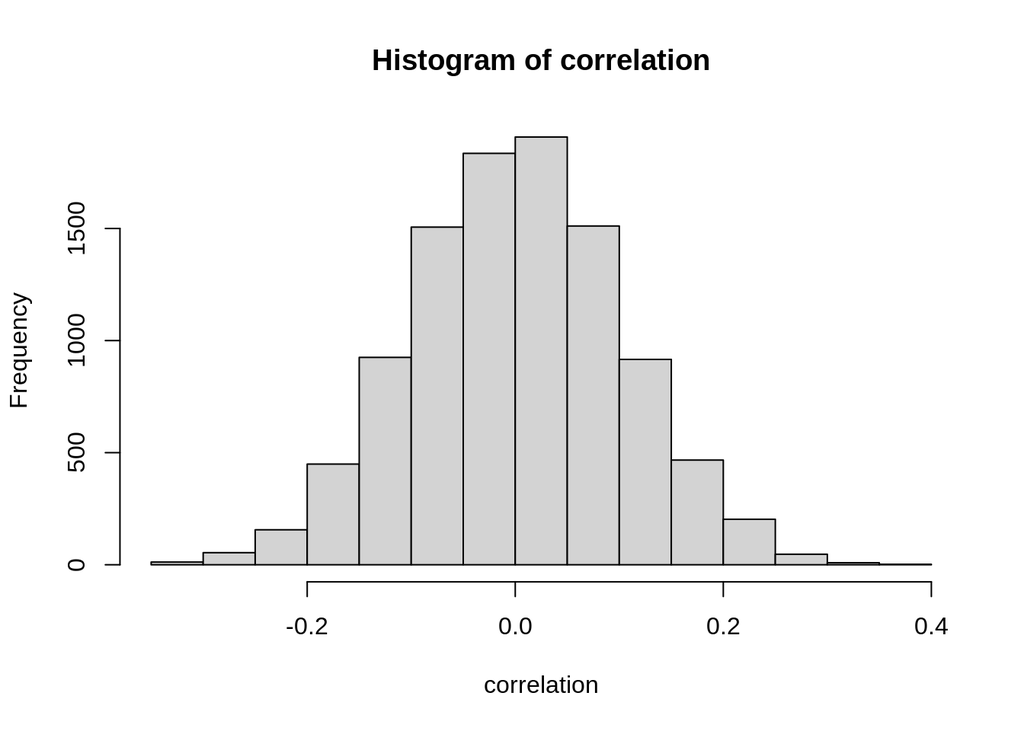

```r
hist(cor(x[, c(1:10000)], y), xlab = "correlation", main = "Histogram of correlation")
```

```r
df <- tibble(index = c(1:10000) , correlation = abs(cor(x[, c(1:10000)], y)))
```

```r
top10 <- top_n(df, 10, correlation)
top10
```

```
## # A tibble: 10 × 2
##    index correlation[,1]
##    <int>           <dbl>
##  1   570           0.347
##  2   571           0.331
##  3  1932           0.353
##  4  3702           0.341
##  5  4456           0.329
##  6  5495           0.337
##  7  6638           0.347
##  8  7120           0.351
##  9  7335           0.343
## 10  7858           0.331
```

#### b).

```r
set.seed(2)
train <- sample(100, 50)
train.X <- x[train, ]
val.X <- x[-train, ]

train.Y <- y[train]
val.Y <- y[-train]
lm_3 <- lm(train.Y ~ train.X[, top10$index])
mean((predict(lm_3, data.frame(val.X[, top10$index])) - val.Y)^2)
```

```
## [1] 2.06412
```

The estimate test error is 2.06412

#### c).

```r
set.seed(2)
train <- sample(100, 50)
train.X <- x[train, ]
val.X <- x[-train, ]

train.Y <- y[train]
val.Y <- y[-train]
df2 <- tibble(index = c(1:10000) , correlation = abs(cor(train.X[, c(1:10000)], train.Y)))

top_10 <- top_n(df2, 10, correlation)

lm_4 <- lm(train.Y ~ train.X[, top_10$index])
mean((predict(lm_4, data.frame(val.X[, 1:10])) - val.Y)^2)
```

```
## [1] 2.412336
```

The estimate test error is 2.412336

#### d).

The estimate test error for option 2 is larger. The option 1 is useless because it find the correlation data before setting up the train and val data. The val data should only be used when we want to check the error for our model. The correlation data in option1 may be divided into val data after we calculate it which is a wrong approach.

### Problem 3

#### a).

```r
super <- read.csv("Superconductivty.csv")
```

I get data from https://archive.ics.uci.edu/ml/datasets/Superconductivty+Data. It’s about superconductivity. It has 81 features extracted from 21263 superconductors along with the critical temperature(y) All the column except the 82th are the predictors which are physics-related factors that may effect the critical temperature.

#### b).

```r
lm_5 <- lm(critical_temp ~ .-critical_temp, super)
summary(lm_5)
```

```
##
## Call:
## lm(formula = critical_temp ~ . - critical_temp, data = super)
##
## Residuals:
##     Min      1Q  Median      3Q     Max
## -84.987  -9.370   0.595  10.976 171.246
##
## Coefficients:
##                                   Estimate Std. Error t value Pr(>|t|)
## (Intercept)                     -2.081e+01  4.991e+00  -4.169 3.07e-05 ***
## number_of_elements              -3.496e+00  7.480e-01  -4.674 2.97e-06 ***
## mean_atomic_mass                 8.480e-01  8.274e-02  10.249  < 2e-16 ***
## wtd_mean_atomic_mass            -9.041e-01  1.031e-01  -8.773  < 2e-16 ***
## gmean_atomic_mass               -5.102e-01  8.194e-02  -6.226 4.86e-10 ***
## wtd_gmean_atomic_mass            6.468e-01  9.764e-02   6.625 3.57e-11 ***
## entropy_atomic_mass             -3.596e+01  4.599e+00  -7.819 5.58e-15 ***
## wtd_entropy_atomic_mass          4.555e+00  3.638e+00   1.252 0.210617
## range_atomic_mass                2.142e-01  1.653e-02  12.957  < 2e-16 ***
## wtd_range_atomic_mass            2.598e-02  2.208e-02   1.177 0.239203
## std_atomic_mass                 -5.608e-01  6.276e-02  -8.936  < 2e-16 ***
## wtd_std_atomic_mass              9.048e-02  5.465e-02   1.656 0.097782 .
## mean_fie                         1.601e-01  6.339e-02   2.526 0.011553 *
## wtd_mean_fie                    -1.787e-01  7.733e-02  -2.311 0.020843 *
## gmean_fie                       -1.524e-01  6.265e-02  -2.432 0.015012 *
## wtd_gmean_fie                    1.984e-01  7.637e-02   2.598 0.009379 **
## entropy_fie                     -1.187e+02  2.019e+01  -5.879 4.19e-09 ***
## wtd_entropy_fie                  4.414e+01  4.776e+00   9.243  < 2e-16 ***
## range_fie                        6.821e-02  6.411e-03  10.640  < 2e-16 ***
## wtd_range_fie                    2.147e-02  3.628e-03   5.917 3.32e-09 ***
## std_fie                         -1.986e-01  2.240e-02  -8.866  < 2e-16 ***
## wtd_std_fie                     -2.323e-02  2.061e-02  -1.127 0.259721
## mean_atomic_radius              -5.351e-01  1.798e-01  -2.976 0.002926 **
## wtd_mean_atomic_radius           3.257e+00  2.411e-01  13.507  < 2e-16 ***
## gmean_atomic_radius              2.009e-01  1.801e-01   1.115 0.264757
## wtd_gmean_atomic_radius         -2.862e+00  2.361e-01 -12.124  < 2e-16 ***
## entropy_atomic_radius            7.932e+01  1.760e+01   4.506 6.64e-06 ***
## wtd_entropy_atomic_radius        4.482e+01  5.308e+00   8.445  < 2e-16 ***
## range_atomic_radius              1.952e-01  2.217e-02   8.806  < 2e-16 ***
## wtd_range_atomic_radius         -9.148e-02  1.595e-02  -5.735 9.91e-09 ***
```

[output cut: 43 more lines]

```
## wtd_mean_Valence                 2.443e+01  7.204e+00   3.391 0.000698 ***
## gmean_Valence                    2.126e+01  5.707e+00   3.725 0.000196 ***
## wtd_gmean_Valence               -2.840e+01  6.755e+00  -4.204 2.64e-05 ***
## entropy_Valence                  7.441e+01  1.229e+01   6.054 1.43e-09 ***
## wtd_entropy_Valence             -7.037e+01  5.561e+00 -12.654  < 2e-16 ***
## range_Valence                    4.790e+00  7.316e-01   6.547 6.02e-11 ***
## wtd_range_Valence               -7.827e-01  6.307e-01  -1.241 0.214625
## std_Valence                      6.943e+00  2.449e+00   2.835 0.004590 **
## wtd_std_Valence                 -2.502e+01  1.906e+00 -13.127  < 2e-16 ***
## ---
## Signif. codes:  0 '***' 0.001 '**' 0.01 '*' 0.05 '.' 0.1 ' ' 1
##
## Residual standard error: 17.59 on 21181 degrees of freedom
## Multiple R-squared:  0.7373, Adjusted R-squared:  0.7363
## F-statistic: 733.8 on 81 and 21181 DF,  p-value: < 2.2e-16
```

```r
set.seed(2)
train <- sample(21263, 10632)
super_train<- super[train, ]
super_val <- super[-train, ]

lm_5 <- lm(critical_temp ~ .-critical_temp, super_train)
mean((predict(lm_5, data.frame(super_val)) - super_val$critical_temp)^2)
```

```
## [1] 309.761
```

The estimate error is 309.761. The process is split the data into train and text by sample(21263, 10632). Then fit the least squares linear model through lm for critical_temp with all other predictors. Finally, apply  
critical_temp which is y value in this data and lslm into the function of finding estimate test error through  
validation set approach.

#### c).

```r
library(glmnet)
```

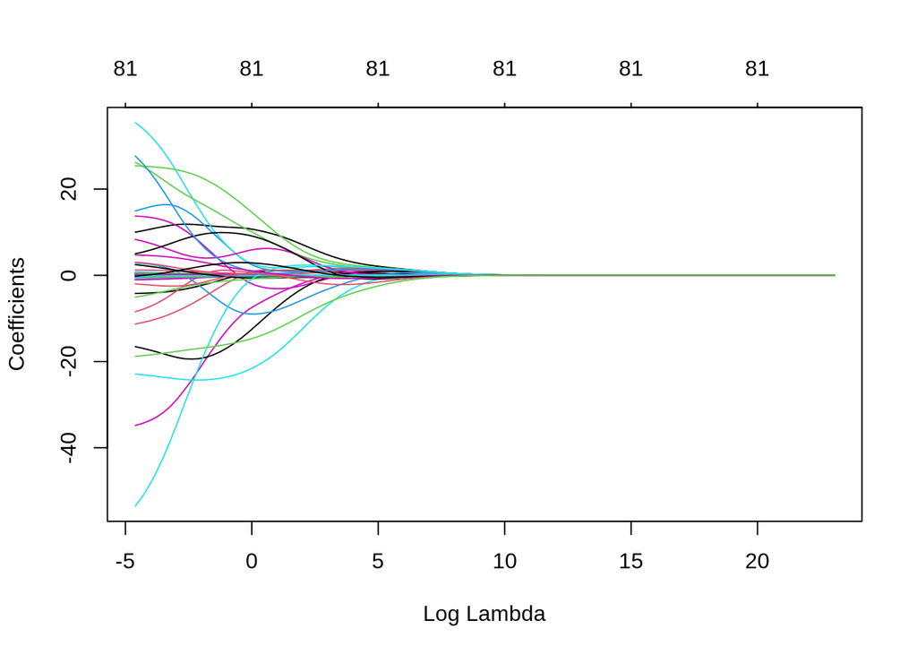

```r
grid <- 10^seq(10, -2, length=100)
ridge.mod <- glmnet(super_train[,1:81], super_train$critical_temp, alpha=0, lambda=grid)
plot(ridge.mod, xvar="lambda")
```

#### d).

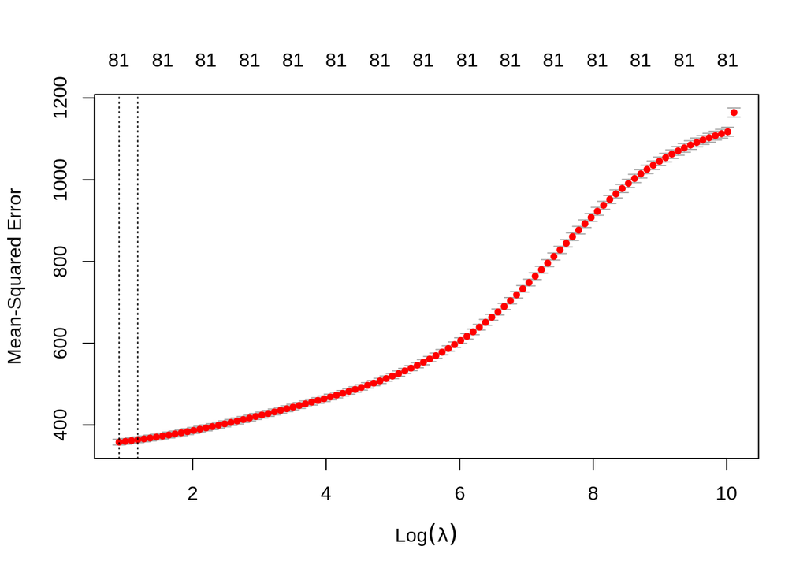

```r
set.seed(2)
cv.out <- cv.glmnet(as.matrix(super_train[,1:81]), as.matrix(super_train$critical_temp), alpha=0)
plot(cv.out)
```

```r
best <- cv.out$lambda.min
best
```

```
## [1] 2.455973
```

```r
min(cv.out$cvm)
```

```
## [1] 358.0746
```

The best lambda is 2.455973. The estimate of test error is 358.0746. I use 10-fold cross validation with default cv.glmnet to get the estimate test error.

#### e).

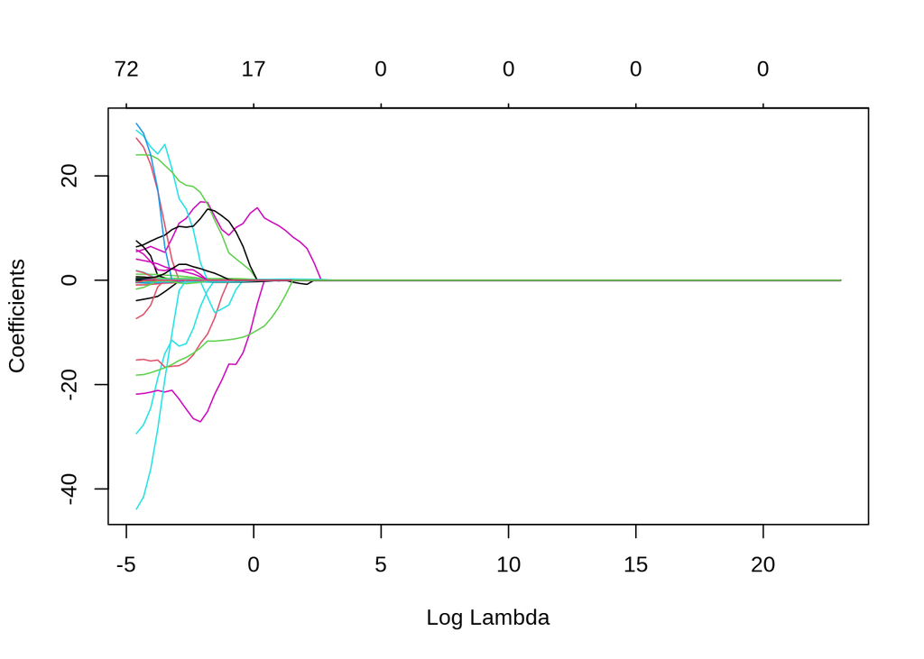

```r
lasso.mod <- glmnet(super_train[,1:81], super_train$critical_temp, alpha=1, lambda=grid)
plot(lasso.mod, xvar="lambda")
```

#### f).

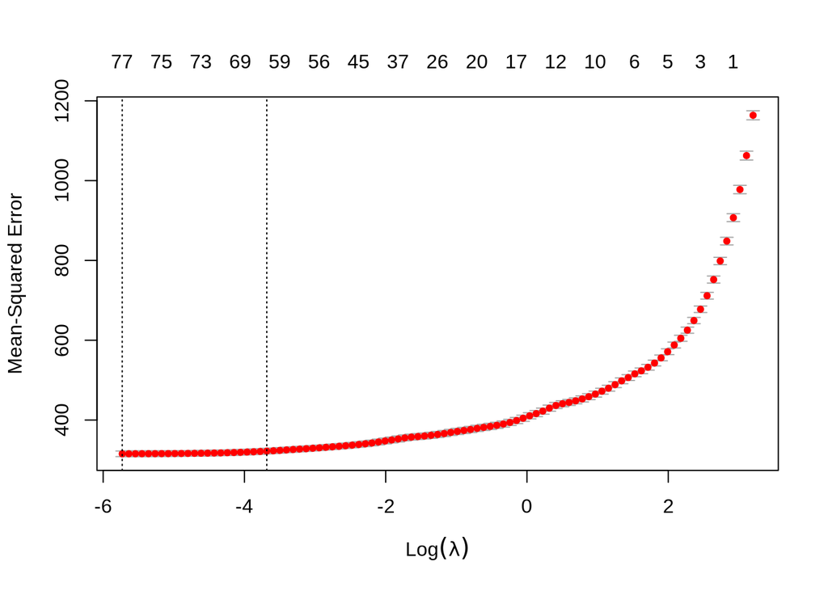

```r
set.seed(2)
cv.out <-cv.glmnet(as.matrix(super_train[,1:81]), as.matrix(super_train$critical_temp), alpha=1)
plot(cv.out)
```

```r
best <- cv.out$lambda.min
best
```

```
## [1] 0.003246651
```

```r
min(cv.out$cvm)
```

```
## [1] 315.4107
```

The best lambda is 0.003246651 with error 315.4107.

```r
coef(cv.out, s = best) # features used in the case
```

```
## 82 x 1 sparse Matrix of class "dgCMatrix"
##                                            s1
## (Intercept)                     -2.123441e+01
## number_of_elements              -3.867426e+00
## mean_atomic_mass                 3.343152e-01
## wtd_mean_atomic_mass            -2.364997e-01
## gmean_atomic_mass               -1.865821e-02
## wtd_gmean_atomic_mass            1.028465e-02
## entropy_atomic_mass             -3.457840e+01
## wtd_entropy_atomic_mass          6.296004e+00
## range_atomic_mass                2.071617e-01
## wtd_range_atomic_mass           -3.406734e-04
## std_atomic_mass                 -2.484008e-01
## wtd_std_atomic_mass             -2.639544e-01
## mean_fie                         9.639401e-03
## wtd_mean_fie                     1.221111e-02
## gmean_fie                        .
## wtd_gmean_fie                    .
## entropy_fie                     -9.281330e-02
## wtd_entropy_fie                  3.349964e+01
## range_fie                        5.189232e-02
## wtd_range_fie                    2.073770e-02
## std_fie                         -1.386516e-01
## wtd_std_fie                     -1.930411e-02
## mean_atomic_radius               8.768210e-01
## wtd_mean_atomic_radius           5.505527e-01
## gmean_atomic_radius             -1.124918e+00
## wtd_gmean_atomic_radius         -2.195922e-01
## entropy_atomic_radius           -1.900857e+00
## wtd_entropy_atomic_radius        3.083377e+01
## range_atomic_radius              2.646545e-01
## wtd_range_atomic_radius         -1.032954e-01
## std_atomic_radius               -1.062145e+00
## wtd_std_atomic_radius            4.030391e-01
## mean_Density                    -3.846690e-03
## wtd_mean_Density                 .
## gmean_Density                    5.325150e-04
## wtd_gmean_Density                1.666440e-03
## entropy_Density                  1.089921e+01
## wtd_entropy_Density             -1.495472e+01
```

[output cut: 29 more lines]

```
## wtd_entropy_ThermalConductivity  4.936770e+00
## range_ThermalConductivity       -6.493177e-02
## wtd_range_ThermalConductivity   -1.902554e-01
## std_ThermalConductivity          1.840980e-01
## wtd_std_ThermalConductivity      4.386286e-02
## mean_Valence                     4.187933e-01
## wtd_mean_Valence                 .
## gmean_Valence                    2.511131e+00
## wtd_gmean_Valence               -2.573143e+00
## entropy_Valence                  3.732104e+01
## wtd_entropy_Valence             -5.387729e+01
## range_Valence                    4.678044e+00
## wtd_range_Valence               -6.555732e-02
## std_Valence                     -1.148647e+00
## wtd_std_Valence                 -1.845151e+01
```

### Problem 4

```r
library(ISLR2)
head(Auto)
```

```
##   mpg cylinders displacement horsepower weight acceleration year origin
## 1  18         8          307        130   3504         12.0   70      1
## 2  15         8          350        165   3693         11.5   70      1
## 3  18         8          318        150   3436         11.0   70      1
## 4  16         8          304        150   3433         12.0   70      1
## 5  17         8          302        140   3449         10.5   70      1
## 6  15         8          429        198   4341         10.0   70      1
##                        name
## 1 chevrolet chevelle malibu
## 2         buick skylark 320
## 3        plymouth satellite
## 4             amc rebel sst
## 5               ford torino
## 6          ford galaxie 500
```

#### a).

```r
set.seed(1)
k <- 10
train <- sample(392, 196)
MSE_mat <- matrix(NA, k, 10)
MSE <-rep(0, 10)
attach(Auto)
```

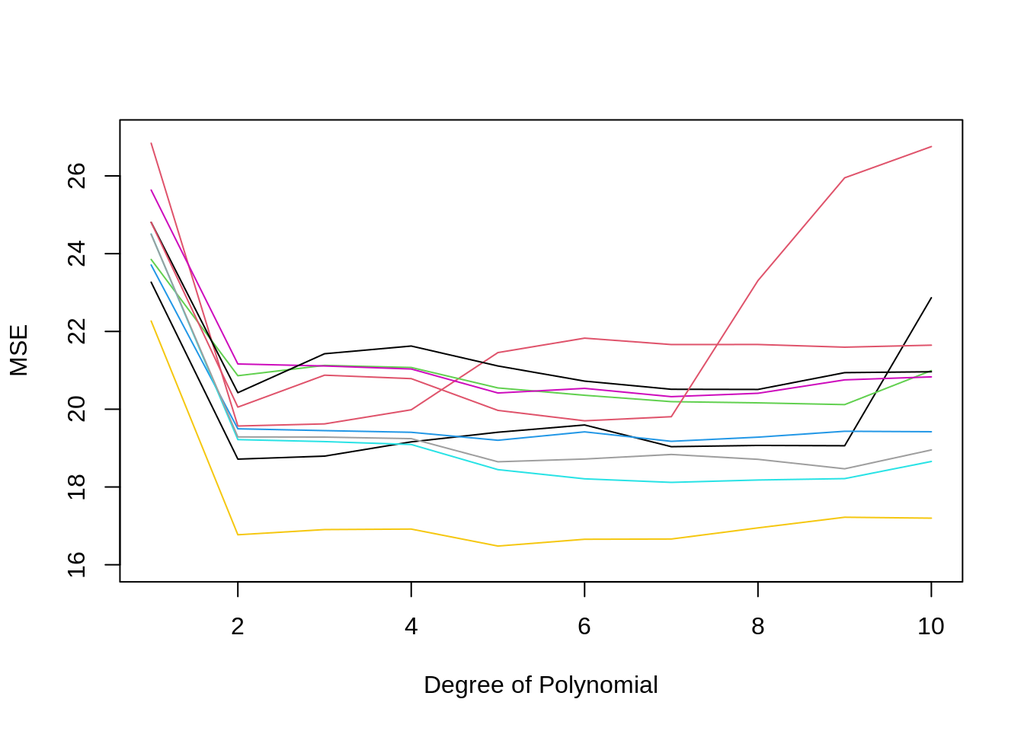

```r
for (i in 1:10) {
    lm.fit <- lm(mpg ~ poly(horsepower, i), data = Auto, subset = train)
    MSE[i] = mean((mpg - predict(lm.fit, Auto))[-train]^2)
    MSE_mat[1,i] = mean((mpg - predict(lm.fit, Auto))[-train]^2)
}

plot(1:10, MSE, type = "l", xlab = "Degree of Polynomial", ylim = c(16,27))

for (j in 2:10) {
  train <- sample(392, 196)
  for (i in 1:10) {
    lm.fit <- lm(mpg ~ poly(horsepower, i), data = Auto, subset = train)
    MSE[i] =mean((mpg - predict(lm.fit, Auto))[-train]^2)
    MSE_mat[j, i] = mean((mpg - predict(lm.fit, Auto))[-train]^2)
  }
  lines(1:10, MSE, col = j)
}
```

```r
ave_mse <- round(apply(MSE_mat, 2, mean), 3)
ave_mse
```

```
##  [1] 24.419 19.556 19.776 19.832 19.569 19.574 19.433 19.824 20.176 20.828
```

```r
which.min(ave_mse)
```

```
## [1] 7
```

#### b).

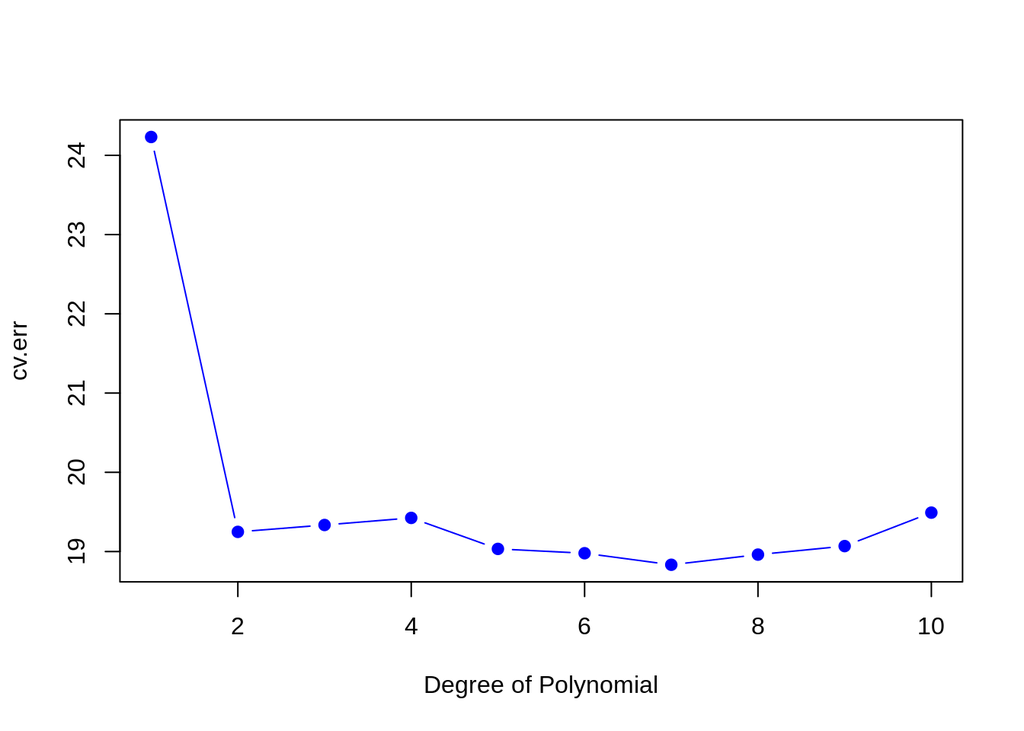

```r
set.seed(1)
cv.err <- rep(0, 10)
for (i in 1:10) {
    glm.fit <- glm(mpg ~ poly(horsepower, i), data = Auto)
    cv.err[i] <- cv.glm(Auto, glm.fit)$delta[1]
}
plot(1:10, cv.err, type = "b", xlab = "Degree of Polynomial", pch = 19, col = "blue")
```

```r
cv.err
```

```
##  [1] 24.23151 19.24821 19.33498 19.42443 19.03321 18.97864 18.83305 18.96115
##  [9] 19.06863 19.49093
```

```r
which.min(cv.err)
```

```
## [1] 7
```

The degree polynomial of 7 is the best because it has the smallest MSE 18.83305. The degree polynomial of 1 is the worst since its MSE is 24.23151 which is the largest one. The error doesn’t have an obvious change after degree of 2.

#### c).

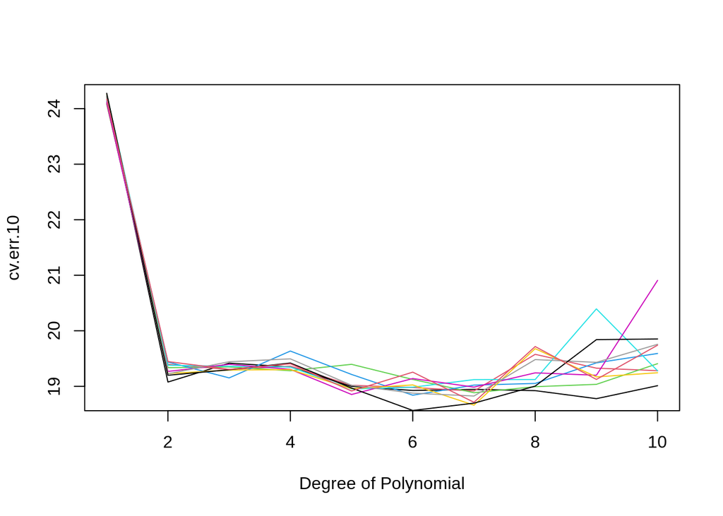

```r
set.seed(1)
cv.err.10 <- rep(0, 10)
cv.err.10.mat <- matrix(NA, 10, 10)
for (i in 1:10) {
    glm.fit <- glm(mpg ~ poly(horsepower, i), data = Auto)
    cv.err.10[i] <- cv.glm(Auto, glm.fit, K = 10)$delta[1]
    cv.err.10.mat[1, i] <- cv.glm(Auto, glm.fit, K = 10)$delta[1]
}
plot(1:10, cv.err.10, type = "l", xlab = "Degree of Polynomial")

for (j in 2:10) {
  for (z in 1:10) {
    glm.fit <- glm(mpg ~ poly(horsepower, z), data = Auto)
    cv.err.10[z] <- cv.glm(Auto, glm.fit, K = 10)$delta[1]
    cv.err.10.mat[j, z] <- cv.glm(Auto, glm.fit, K = 10)$delta[1]
  }
  lines(1:10, cv.err.10, col = j)
}
```

```r
ave_cv.err.10.mat <- round(apply(cv.err.10.mat, 2, mean), 3)
ave_cv.err.10.mat
```

```
##  [1] 24.239 19.327 19.405 19.464 19.052 19.011 18.833 19.070 19.199 19.512
```

```r
which.min(ave_cv.err.10.mat)
```

```
## [1] 7
```

The degree polynomial of 7 is the best because it has the smallest MSE 18.833 The degree polynomial of 1 is the worst since its MSE is 24.239 which is the largest one. Same idea as previous, error has negligible change after degree of 2 and there are also obvious increases at 8 and 9.

#### d).

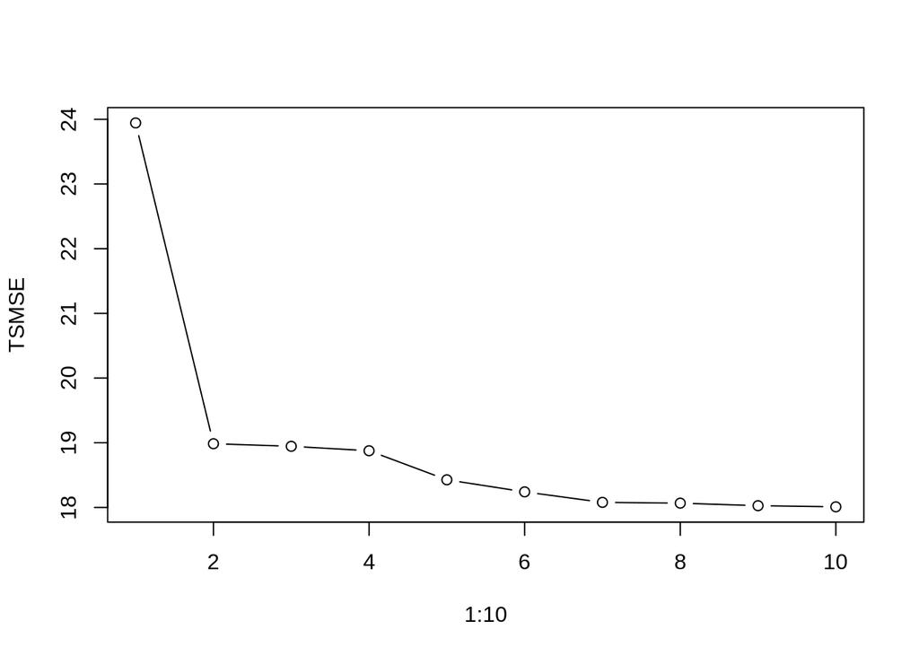

```r
set.seed(1)
TSMSE <- rep(0,10)
for (i in 1:10) {
    lm.fit2 <- lm(mpg ~ poly(horsepower, i), data = Auto)
    TSMSE[i] = mean((mpg - predict(lm.fit2, Auto))^2)
}

plot(1:10, TSMSE, type = "b", col = 1)
```

When the degree increases, the MSE decreases, but still after degree of 2, the decreases is small. However when we have a too good model with a high degree, it will lead to the overfitting eventually.

#### e).

```r
set.seed(1)
TSMSE10 <- 0
lm.fit3 <- lm(mpg ~ poly(horsepower, 10), data = Auto)
pred <- predict(lm.fit3, data.frame(mpg))
summary(pred)
```

```
##    Min. 1st Qu.  Median    Mean 3rd Qu.    Max.
##   11.15   18.71   23.06   23.45   29.51   35.04
```

```r
summary(lm.fit3)
```

```
##
## Call:
## lm(formula = mpg ~ poly(horsepower, 10), data = Auto)
##
## Residuals:
##      Min       1Q   Median       3Q      Max
## -15.7081  -2.5904  -0.1922   2.2859  14.8338
##
## Coefficients:
##                         Estimate Std. Error t value Pr(>|t|)
## (Intercept)              23.4459     0.2174 107.840   <2e-16 ***
## poly(horsepower, 10)1  -120.1377     4.3046 -27.909   <2e-16 ***
## poly(horsepower, 10)2    44.0895     4.3046  10.242   <2e-16 ***
## poly(horsepower, 10)3    -3.9488     4.3046  -0.917   0.3595
## poly(horsepower, 10)4    -5.1878     4.3046  -1.205   0.2289
## poly(horsepower, 10)5    13.2722     4.3046   3.083   0.0022 **
## poly(horsepower, 10)6    -8.5462     4.3046  -1.985   0.0478 *
## poly(horsepower, 10)7     7.9806     4.3046   1.854   0.0645 .
## poly(horsepower, 10)8     2.1727     4.3046   0.505   0.6140
## poly(horsepower, 10)9    -3.9182     4.3046  -0.910   0.3633
## poly(horsepower, 10)10   -2.6146     4.3046  -0.607   0.5440
## ---
## Signif. codes:  0 '***' 0.001 '**' 0.01 '*' 0.05 '.' 0.1 ' ' 1
##
## Residual standard error: 4.305 on 381 degrees of freedom
## Multiple R-squared:  0.7036, Adjusted R-squared:  0.6958
## F-statistic: 90.45 on 10 and 381 DF,  p-value: < 2.2e-16
```

The max prediction is 35.04, min is 11.15, median is 23.06. All the error from a-d are in this range. Based on our finding, the degree of 2 is relatively better since the all models have a turning point at 2. After this point, the decreases of the error becomes less important since it wont make a huge difference on error, while bringing potential overfit into the model.

### Problem 5

#### a).

$$\begin{align}
\text{In order to find the min of the function, we have }
\frac{\partial}{\partial \beta}\sum_{i=1}^{n}{(y_i-\beta x_i)^2} = 0 \\
\frac{\partial}{\partial \beta}\sum_{i=1}^{n}{(y_i^2-2y_i\beta x_i +
\beta^2 x_i^2)} &= 0 \\
\sum_{i=1}^{n}{(-2y_i x_i + 2\beta x_i^2)} &= 0\\
\sum_{i=1}^{n}{(-y_i x_i + \beta x_i^2)} &= 0 \\
\beta =\frac{\sum x_iy_i}{\sum x_i^2}
\end{align}$$

#### b).

$$\begin{align}
\text{In order to find the min of the function, we have }
\frac{\partial}{\partial \beta}\sum_{i=1}^{n}{(y_i-\beta x_i)^2} +
\lambda \beta^2 = 0 \\
\frac{\partial}{\partial \beta}\sum_{i=1}^{n}{(y_i^2-2y_i\beta x_i +
\beta^2 x_i^2)} + \lambda \beta^2 &= 0\\
\sum_{i=1}^{n}{(-2y_i x_i + 2\beta x_i^2)} + 2 \lambda \beta &= 0\\
\sum_{i=1}^{n}{(-y_i x_i + \beta x_i^2)} + \lambda \beta &= 0 \\
\sum_{i=1}^{n}{-y_i x_i} + \beta \sum_{i=1}^{n}{ x_i^2} + \lambda \beta
&= 0 \\
\beta =\frac{\sum x_iy_i}{\sum x_i^2 + \lambda}
\end{align}$$
#### c).

#### d).

$$\begin{align}
\beta = 3\\
E[\beta] &= E[\frac{\sum x_iy_i}{\sum x_i^2 + \lambda}] \\
&= E[\frac{\sum x_i(3x_i + \epsilon)}{\sum x_i^2 + \lambda}] \\
&= E[\frac{\sum (3x_i^2+ x_i\epsilon)}{\sum x_i^2 + \lambda}] \\
& \text{Since } \epsilon \text{ has mean zero }
E[\beta] = 3E[\frac{\sum (x_i^2)}{\sum x_i^2 + \lambda}] \neq \beta
\text{ ,which means it's biased in this case.} \\
& \text{The expectation change since we can't elimiate the xi
from the fraction with the } \lambda \\
& \text{on the denomiator when it not 0. However when it decreases
towards a small number} \\
&\text{the expectation will toward to large expectation.}
\end{align}$$
#### e).

$$\begin{align}
\beta = 3, cov(x_i, y_i) = 0 \text{ for } i \neq i'\\
Var[\beta] &= Var[\frac{\sum x_iy_i}{\sum x_i^2}] \\
&= Var[\frac{\sum x_i(3x_i + \epsilon)}{\sum x_i^2}] \\
&= Var[\frac{(\sum 3x_i^2 +x_i\epsilon)}{\sum x_i^2}] \\
&= Var[3 + \frac{\epsilon\sum x_i}{\sum x_i^2}] \\
&= Var[\frac{\epsilon\sum x_i}{\sum x_i^2}] \\
&= (\frac{1}{\sum x_i^2})^2*(\sum x_i^2) Var(\epsilon) \\
&= \frac{\sigma^2}{\sum x_i^2}
\end{align}$$

#### g).

$$\begin{align}
Bias[\beta]^2 &= (E[\beta]-\beta)^2 \\
&= (\frac{\beta\sum (x_i^2)}{\sum x_i^2 + \lambda}-\beta)^2 \\
&= \beta^2(\frac{\lambda}{\sum x_i^2 + \lambda})^2
\end{align}$$

Thus a larger penalty in ridge-regression reduces the variance and increases the bias and squared bias value which observe a  
trade-off.